# SEIR Metapopulation Contact Model

## Links to local data sets

Here we use the following links to data.

```r
GADM_census_path <- "~/Desktop/OUCRU/FacebookData/ColocationMarc/GADM_census.rds"
coloc_mat_path <- "~/Desktop/OUCRU/FacebookData/ColocationMarc/coloc_mat.rds"
GADM_country_path <- "~/Desktop/OUCRU/FacebookData/ColocationMarc/gadm36_VNM_0_sf.rds"
```

Change them accordingly if you want to run the script locally on your computer.

## Read in local data sets

```r
dist_polygons <- readRDS(GADM_census_path)
coloc_mat <- readRDS(coloc_mat_path)
vn0 <- readRDS(GADM_country_path)
```

## Packages

The needed packages:

```r
library(sf)
library(stars)
library(tidyr)
library(purrr)
library(dplyr) # best to load last
library(reshape2)
library(data.table)
library(ggplot2)
```

Redefining the `hist()` function:

```r
hist2 <- function(...) hist(..., main = NA)
```

## SEIR Metapopulation Contact Model

The following model uses colocation data to formulate the coupling in a SEIR metapopulation model. The equations that describe the epidynamics in each of the populations is given below:
$$\begin{aligned}
\frac{dS_i}{dt} & = - S_i \sum_{k} \beta_{ik} \frac{I_k}{N_k} \\
\frac{dE_i}{dt} & = S_i \sum_{k} \beta_{ik} \frac{I_k}{N_k} - \sigma E_i \\
\frac{dI_i}{dt} & = \sigma E_i - \gamma I_i \\
\frac{dR_i}{dt} & = \gamma I_i \\
\end{aligned}$$
where $\frac{1}{\sigma} = 7$ days is the latency period and $\frac{1}{\gamma} = 7$ is the recovery period. Note that $N_i = S_i + E_i + I_i + R_i$. We assume that $\beta_{ik}$ which represents the transmission rate from population $k$ to population $i$ is proportional to $C_{ik}$, the colocation probability for population $i$ and population $k$.

## Parameterization Method 1

The following parameterization is an adaptation of the contact model given in the paper, [Modeling the impact of human mobility and travel restrictions on the potential spread of SARS-CoV-2 in Taiwan](https://www.medrxiv.org/content/10.1101/2020.04.07.20053439v1).

The $\beta_{ik}$ are defined as follows:
$$\begin{aligned}
\beta_{ik} = \gamma R_{0 ik}
\end{aligned}$$
where
$$\begin{aligned}
R_{0 ik} & = R_{0 \: Hanoi'} \frac{C_{ij}}{C_{Hanoi'-Hanoi'}} \\
\end{aligned}$$
and $Hanoi'$ is the district in Hà Nội with the highest density.

Let’s calculate the district in Hanoi with the highest density.

```r
HanoiDist <- dist_polygons %>%
  filter(province == "Hà Nội") %>%
  arrange(desc(den_km2)) %>%
  head(1) %>%
  pull(district)

HanoiDistID <- dist_polygons %>%
  filter(province == "Hà Nội") %>%
  filter(district == HanoiDist) %>%
  pull(polygon_id)
```

As such, we will set the $R_0$ of Hoàn Kiếm to 18; that is, $R_{0 \: Hanoi'} = 18$.

The following function computes the $R_{0 ik}$ values with the standard reference district with $R_0$ of `standardR0` and district ID of `standardDistID`.

```r
compute_R0 <- function(coloc_mat, standardR0, standardDistID) {
  melt(coloc_mat) %>%
    setNames(c("polygon1_id", "polygon2_id", "link_value")) %>%
    mutate(R0 = standardR0 * link_value / coloc_mat[paste(standardDistID), paste(standardDistID)])
}
```

Let’s compute the $R_{0 ik}$ with $R_{0 \: Hanoi'} = 18$:

```r
R0 <- compute_R0(coloc_mat, 18, HanoiDistID)
```

### Intracity $R_0$

Let’s see the distribution of the intracity $R_0$ values; that is, the distribution of $R_{0 ii}$ values.

```r
intracityR0 <- R0 %>%
  filter(polygon1_id == polygon2_id) %>%
  rename(intraR0 = R0)
```

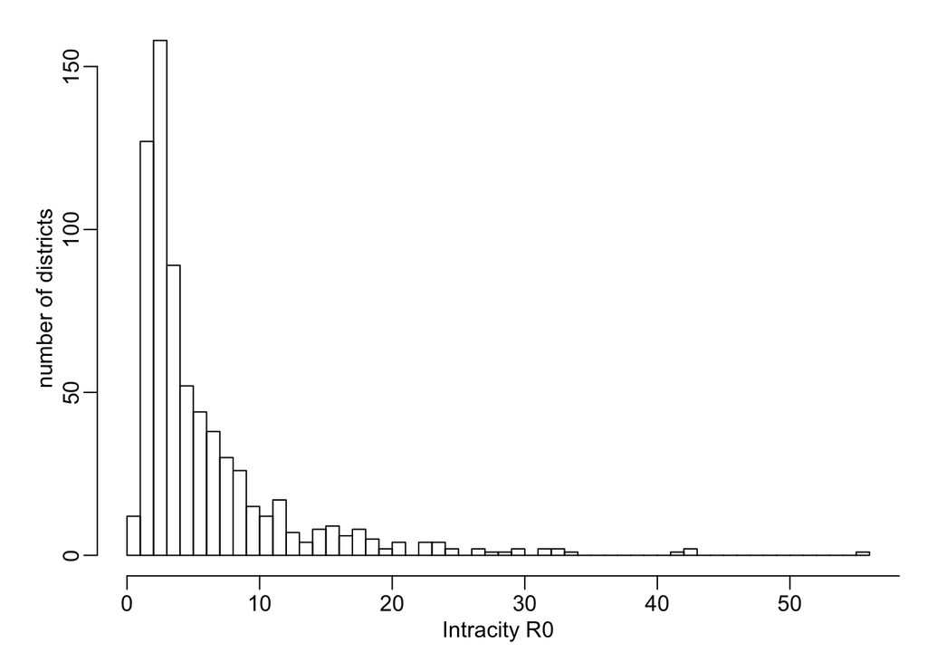

```r
hist2(intracityR0$intraR0, n = 50, xlab = "Intracity R0", ylab = "number of districts", axes = FALSE)
axis(1, seq(0, 60, 10))
axis(2)
```

```r
cb <- RColorBrewer::brewer.pal(9, "YlOrBr")
color_generator <- colorRampPalette(cb)
pal <- color_generator(10)
```

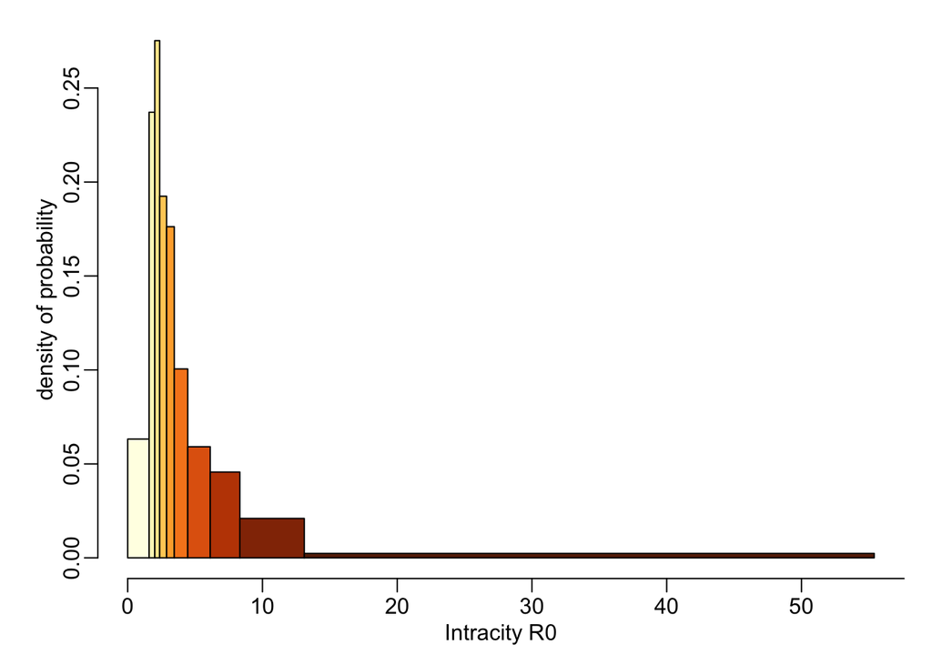

```r
hist2(intracityR0$intraR0, quantile(intracityR0$intraR0, seq(0, 1, le = 11)), col = pal, axes = FALSE,
      xlab = "Intracity R0", ylab = "density of probability")
axis(1, seq(0, 60, 10))
axis(2)
```

```r
quantile(intracityR0$intraR0, seq(0, 1, le = 11))
```

```
##        0%       10%       20%       30%       40%       50%       60%       70%
##  0.000000  1.586063  2.008983  2.373354  2.887077  3.456204  4.453696  6.125704
##       80%       90%      100%
##  8.322006 13.101921 55.396777
```

Let’s map the intracity $R_0$ values for the districts:

```r
intracityR0sf <- dist_polygons %>%
  right_join(select(intracityR0, -polygon2_id), c("polygon_id" = "polygon1_id"))
```

The following district have intracity $R0$ greater than 10.

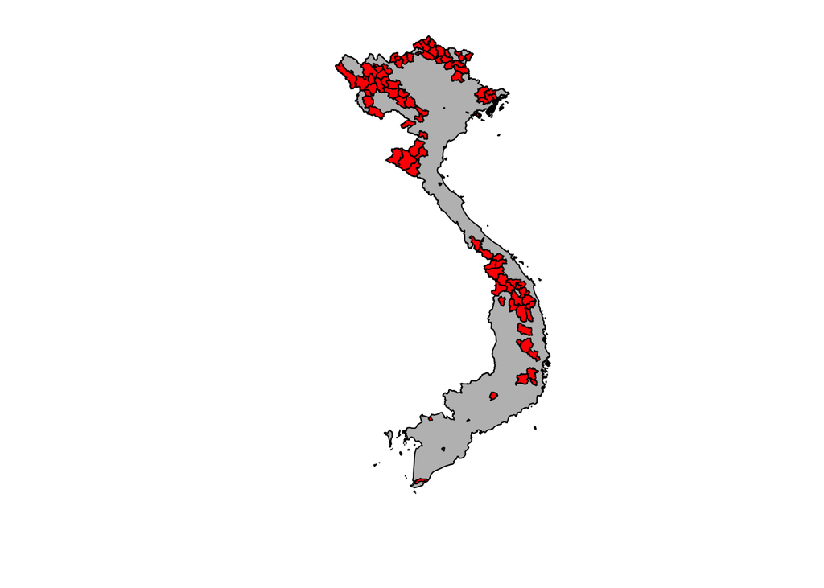

```r
vn0 %>%
  st_geometry() %>%
  plot(col = "grey")

intracityR0sf %>%
  select("intraR0") %>%
  filter(intraR0 > 10) %>%
  plot(add = TRUE, col = "red")
```

The following districts have intracity $R0$ greater than 20.

```r
intracityR0sf %>%
  filter(intraR0 > 20) %>%
  arrange(desc(intraR0)) %>%
  st_drop_geometry() %>%
  select(province, district, intraR0)
```

```
##       province       district  intraR0
## 1      Yên Bái       Trạm Tấu 55.39678
## 2     Hà Giang   Hoàng Su Phì 42.67776
## 3    Quảng Nam      Tây Giang 42.55601
## 4   Quảng Ngãi        Tây Trà 41.49006
## 5      Kon Tum      Kon Plông 33.77775
## 6    Thanh Hóa      Mường Lát 32.71860
## 7       Sơn La        Sốp Cộp 32.20555
## 8    Quảng Nam      Phước Sơn 31.46382
## 9     Hà Giang        Xín Mần 31.07934
## 10    Hà Giang       Đồng Văn 29.85194
## 11  Quảng Ngãi         Lý Sơn 29.61061
## 12    Hà Giang        Mèo Vạc 28.03566
## 13    Cao Bằng        Bảo Lạc 27.90237
## 14   Quảng Nam     Nam Trà My 26.41899
## 15    Lạng Sơn       Đình Lập 26.37892
## 16    Cao Bằng        Bảo Lâm 24.83981
## 17      Sơn La        Bắc Yên 24.52896
## 18  Quảng Ninh         Ba Chẽ 23.66076
## 19  Quảng Ninh      Bình Liêu 23.55896
## 20   Điện Biên       Tủa Chùa 23.15901
## 21    Cao Bằng     Thông Nông 23.08779
## 22   Điện Biên Điện Biên Đông 22.44800
## 23  Bình Thuận        Phú Quí 22.33890
## 24 Hồ Chí Minh              4 22.28844
## 25     Gia Lai        Ayun Pa 22.03421
## 26    Hà Giang        Quản Bạ 20.98567
## 27 Hồ Chí Minh              3 20.84098
## 28     Lào Cai      Si Ma Cai 20.67039
## 29   Quảng Trị      Quảng Trị 20.22414
```

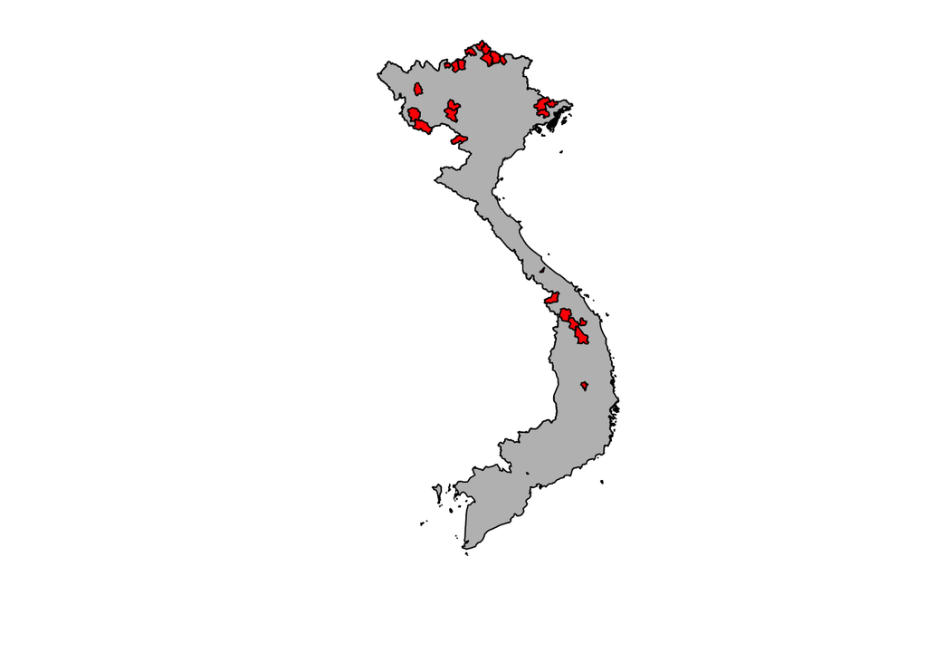

```r
vn0 %>%
  st_geometry() %>%
  plot(col = "grey")

intracityR0sf %>%
  filter(intraR0 > 20) %>%
  select(intraR0) %>%
  plot(add = TRUE, col = "red")
```

It appears that remote regions of Vietnam have relatively higher intracity $R_0$ values. Let’s verify this by graphing relationship between population density and intracity $R_0$ values under the assumption that more remote regions will have lower population densities.

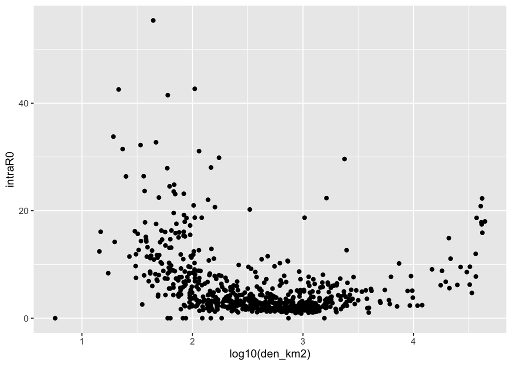

```r
ggplot(intracityR0sf, aes(x = log10(den_km2), y = intraR0)) + geom_point()
```

Both populations with relatively low population densities and populations with relatively high population densities have high intracity $R_0$ values. Populations with especially low densities have the greatest intracity $R_0$ values. Note that we should see a positive relationship between population density and intracity $R_0$ values. The intracity $R_0$ values need to be adjusted to fix the artifact of how the colocation matrix is constructed.

### Intercity $R_0$

Let’s consider the intercity R0 values:

```r
intercityR0 <- R0 %>%
  filter(polygon1_id != polygon2_id) %>%
  rename(interR0 = R0)

totalInter <- intercityR0 %>%
  group_by(polygon1_id) %>%
  summarize(interR0 = sum(interR0)) %>%
  arrange(desc(interR0))
```

Let’s map the intracity $R_0$ values for the districts: The following districts have intercityR0 values greater than 1:

```r
intercityR0sf <- dist_polygons %>%
  right_join(totalInter, c("polygon_id" = "polygon1_id"))
```

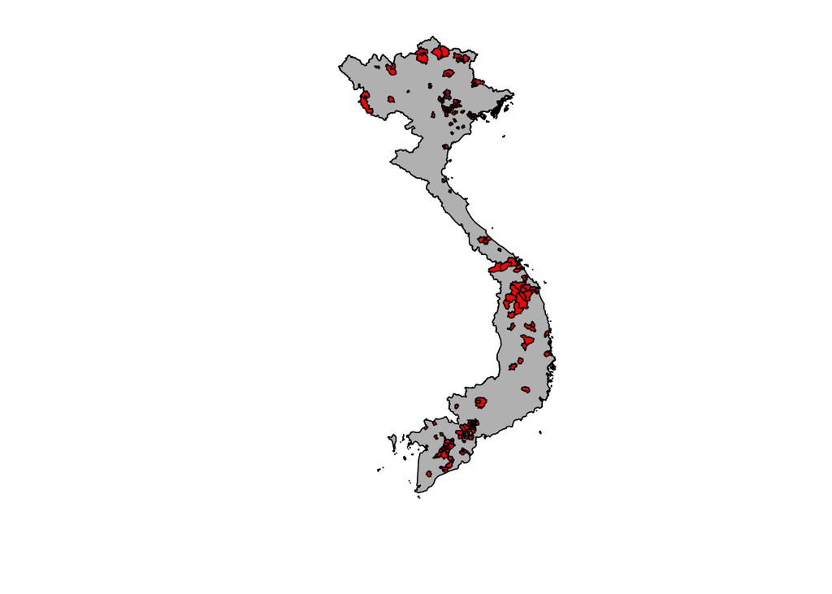

```r
vn0 %>%
  st_geometry() %>%
  plot(col = "grey")

intercityR0sf %>%
  select("interR0") %>%
  filter(interR0 > 1) %>%
  plot(add = TRUE, col = "red")
```

Let’s graph the relationship between population density and intercity $R_0$ values:

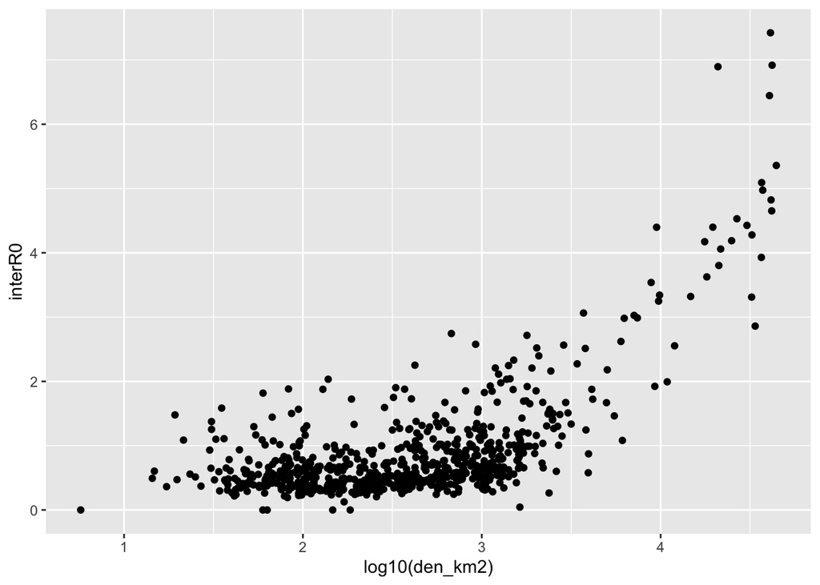

```r
ggplot(intercityR0sf, aes(x = log10(den_km2), y = interR0)) + geom_point()
```

As we would expect, population centers with higher population densities are better connected with surrounding regions resulting in higher intercity $R_0$ values. Hence, the intercity $R_0$ values under this model are consistent with epidemiological assumptions.

### Intercity and Intracity $R_0$ values

Let’s graph the relationship between intracity $R_0$ values and intercity $R_0$ values:

```r
tmp <- intercityR0sf %>%
  right_join(select(intracityR0, -polygon2_id, -link_value), c("polygon_id" = "polygon1_id"))
```

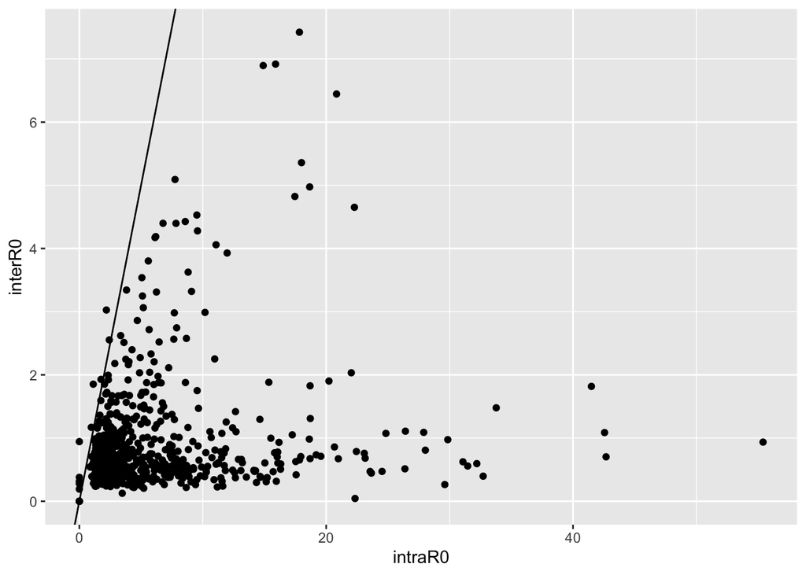

```r
ggplot(tmp, aes(x = intraR0, y = interR0)) + geom_point() +
  geom_abline(slope = 1, intercept = 0)
```

There are two distinct groups in the plot: one group has larger intercity $R_0$ values relative to intracity $R_0$ values, while the other has larger intracity $R_0$ values relative to intercity $R_0$ values.

Let’s use a linear mixture model to assign each point to a particular linear model:

```r
library(flexmix)
set.seed(10)
model <- flexmix(interR0 ~ intraR0, tmp, k = 2)
summary(model)
```

```
##
## Call:
## flexmix(formula = interR0 ~ intraR0, data = tmp, k = 2)
##
##        prior size post>0 ratio
## Comp.1  0.78  574    643 0.893
## Comp.2  0.22  124    666 0.186
##
## 'log Lik.' -498.5177 (df=7)
## AIC: 1011.035   BIC: 1042.873
```

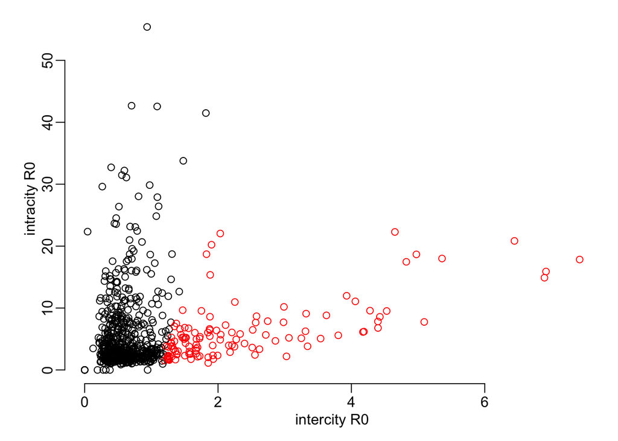

```r
plot(tmp$interR0, tmp$intraR0, col = clusters(model),
     xlab = "intercity R0", ylab = "intracity R0")
```

Let’s map the clustering observed in the linear mixture model to the districts:

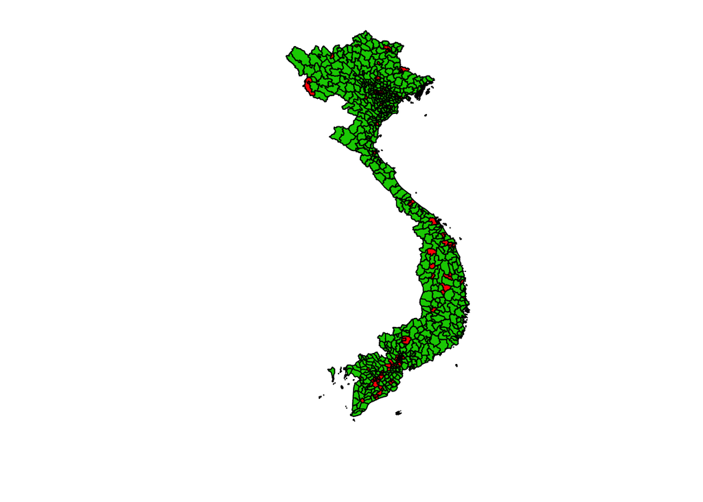

```r
vn0 %>%
  st_geometry() %>%
  plot(col = "grey")

colors <- clusters(model)
colors[colors == 1] = 3

tmp %>%
  transmute(cluster = clusters(model)) %>%
  st_geometry() %>%
  plot(add = TRUE, col = colors)
```

It is a little noisy, so let’s take a closer look at the districts that are “clearly” in one group or the other; that is, districts with posterior probabilities that indicate clear membership to one of the linear regression models.

```r
postProb <- posterior(model) %>%
  as.data.frame() %>%
  transmute(model1 = V1, model2 = V2, cluster = clusters(model)) %>%
  mutate(m1Vm2 = model1/model2, m2Vm1 = model2/model1)
```

```r
tmpPost <- tmp %>%
  transmute(cluster = postProb$cluster, m1Vm2 = postProb$m1Vm2,
            m2Vm1 = postProb$m2Vm1)
```

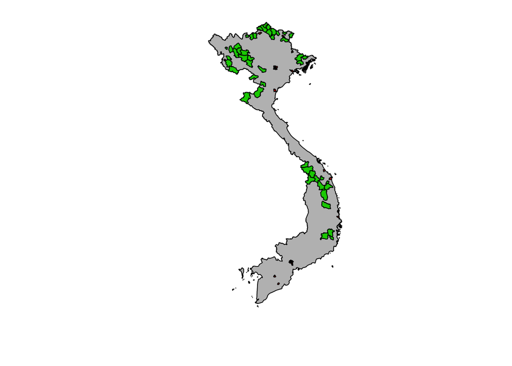

```r
vn0 %>%
  st_geometry() %>%
  plot(col = "grey")

tmpPost %>%
  filter(cluster == 1) %>%
  arrange(desc(m1Vm2)) %>%
  head(50) %>%
  st_geometry() %>%
  plot(add = TRUE, col = 3)

tmpPost %>%
  filter(cluster == 2) %>%
  arrange(desc(m2Vm1)) %>%
  head(50) %>%
  st_geometry() %>%
  plot(add = TRUE, col = 2)
```

The districts with high intercity $R_0$ relative to intracity $R_0$ are clustered around Hanoi and Ho Chi Minh, while the districts with low intercity $R_0$ relative to intracity $R_0$ are clustered in remote regions.

## Parameterization Method 2

The $\beta_{ik}$ are defined as follows:
$$\begin{aligned}
\beta_{ik} = \gamma R_{0 ik}
\end{aligned}$$
where
$$\begin{aligned}
R_{0 ik} & = R_{0 \: Hanoi'} \frac{C_{ij} N_j}{C_{Hanoi'-Hanoi'} \cdot N_{Hanoi'}} \\
\end{aligned}$$
and $Hanoi'$ is the district in Hà Nội with the highest density.

```r
compute_R0 <- function(dist_data, coloc_mat, standardR0, standardDistID) {
  popHanoiDist <- dist_data %>%
    filter(polygon_id == HanoiDistID) %>%
    pull(n)

  coloc_mat <- reshape2::melt(coloc_mat) %>%
    setNames(c("polygon1_id", "polygon2_id", "link_value")) %>%
    dplyr::right_join(select(as.data.frame(dist_data), polygon_id, n),
                      c("polygon2_id" = "polygon_id")) %>%
    dplyr::mutate(R0 = standardR0 * link_value * n /
             (coloc_mat[paste(standardDistID), paste(standardDistID)] * popHanoiDist))
}
```

Let’s compute the $R_{0 ik}$ with $R_{0 \: Hanoi'} = 18$:

```r
R0 <- compute_R0(dist_polygons, coloc_mat, 18, HanoiDistID)
```

### Intracity $R_0$

Let’s see the distribution of the intracity $R_0$ values; that is, the distribution of $R_{0 ii}$ values.

```r
intracityR0 <- R0 %>%
  filter(polygon1_id == polygon2_id) %>%
  rename(intraR0 = R0)
```

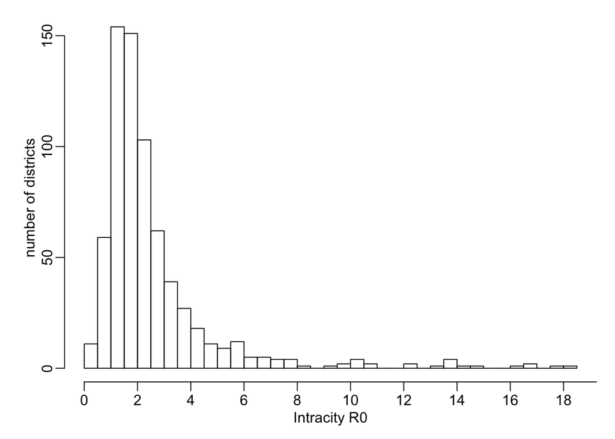

```r
hist2(intracityR0$intraR0, n = 50, xlab = "Intracity R0", ylab = "number of districts", axes = FALSE)
axis(1, seq(0, 20, 2))
axis(2)
```

```r
cb <- RColorBrewer::brewer.pal(9, "YlOrBr")
color_generator <- colorRampPalette(cb)
pal <- color_generator(10)
```

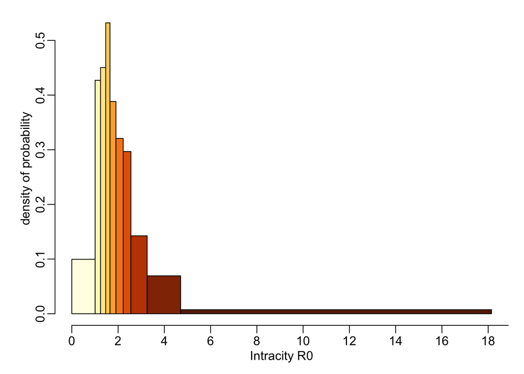

```r
hist2(intracityR0$intraR0, quantile(intracityR0$intraR0, seq(0, 1, le = 11)), col = pal, axes = FALSE,
      xlab = "Intracity R0", ylab = "density of probability")
axis(1, seq(0, 20, 2))
axis(2)
```

```r
quantile(intracityR0$intraR0, seq(0, 1, le = 11))
```

```
##        0%       10%       20%       30%       40%       50%       60%       70%
##  0.000000  1.007264  1.242158  1.464806  1.650588  1.908886  2.221608  2.554752
##       80%       90%      100%
##  3.258339  4.705081 18.142725
```

Let’s map the intracity $R_0$ values for the districts:

```r
intracityR0sf <- dist_polygons %>%
  right_join(select(intracityR0, -polygon2_id, -n), c("polygon_id" = "polygon1_id"))
```

The following district have intracity $R0$ greater than 5.

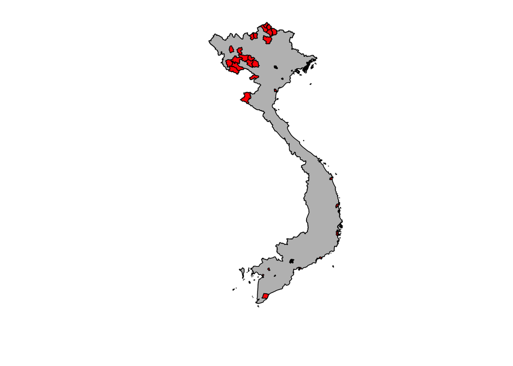

```r
vn0 %>%
  st_geometry() %>%
  plot(col = "grey")

intracityR0sf %>%
  select("intraR0") %>%
  filter(intraR0 > 5) %>%
  plot(add = TRUE, col = "red")
```

While there is slightly more clustering around the population centers of Hanoi and Ho Chi Minh, there is still high intracity $R_0$ values in relatively remote regions.

Let’s explore the relationship between population density and intracity $R_0$ values under the assumption that more remote regions will have lower population densities.

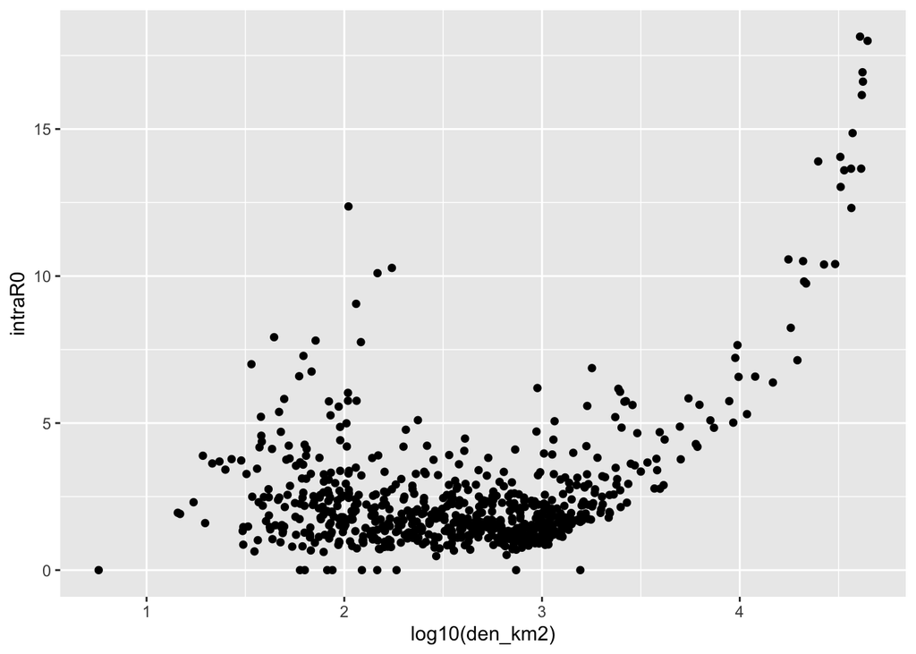

```r
ggplot(intracityR0sf, aes(x = log10(den_km2), y = intraR0)) + geom_point()
```

This is a large improvement from the previous model, but there are still districts with low densities that have high intracity $R_0$ values.

### Intercity $R_0$

Let’s consider the intercity R0 values:

```r
intercityR0 <- R0 %>%
  filter(polygon1_id != polygon2_id) %>%
  rename(interR0 = R0)

totalInter <- intercityR0 %>%
  group_by(polygon1_id) %>%
  summarize(interR0 = sum(interR0)) %>%
  arrange(desc(interR0))
```

Let’s map the intracity $R_0$ values for the districts: The following districts have intercityR0 values greater than 1:

```r
intercityR0sf <- dist_polygons %>%
  right_join(totalInter, c("polygon_id" = "polygon1_id"))
```

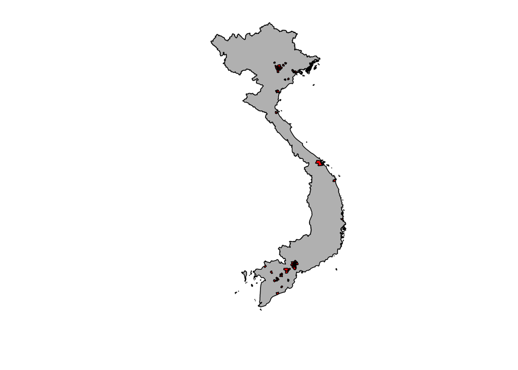

```r
vn0 %>%
  st_geometry() %>%
  plot(col = "grey")

intercityR0sf %>%
  select("interR0") %>%
  filter(interR0 > 1) %>%
  plot(add = TRUE, col = "red")
```

The districts with high intercity $R_0$ values are clustered in high density/highly connected regions including Hanoi and Ho Chi Minh, which is what we would expect.

Let’s graph the relationship between population density and intercity $R_0$ values:

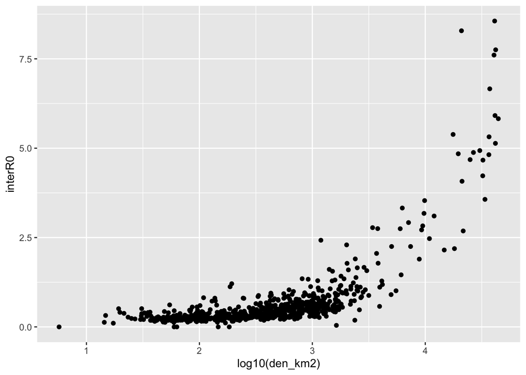

```r
ggplot(intercityR0sf, aes(x = log10(den_km2), y = interR0)) + geom_point()
```

As we would expect, population centers with higher population densities are better connected with surrounding regions resulting in higher intercity $R_0$ values. Hence, the intercity $R_0$ values under this model are consistent with epidemiological assumptions.

### Intercity and Intracity $R_0$ values

Let’s graph the relationship between intracity $R_0$ values and intercity $R_0$ values:

```r
tmp <- intercityR0sf %>%
  right_join(select(intracityR0, -polygon2_id, -link_value), c("polygon_id" = "polygon1_id"))
```

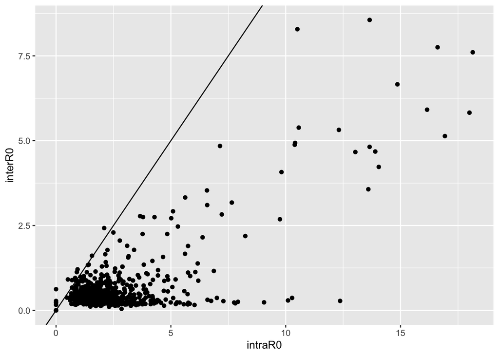

```r
ggplot(tmp, aes(x = intraR0, y = interR0)) + geom_point() +
  geom_abline(slope = 1, intercept = 0)
```

The grouping that we observed in the first model has largely disappeared. There are a few disticts with high intracity $R_0$ values in comparison to intercity $R_0$ which may be a point of concern. As we would expect, however, the intracity $R_0$ values are weakly proportional to the intercity $R_0$ values.

### Risk of Infection

Let’s define the risk of infection for a location $i$ as follows:
$$\begin{aligned}
\text{Risk of infection for location i} = \frac{\sum_{j} R_{0 ij}}{\text{max}_l(\sum_j R_{0 ij})}
\end{aligned}$$

Let’s calculate it for all districts:

```r
ROIdf <- R0 %>%
  group_by(polygon1_id) %>%
  summarize(ROI = sum(R0)) %>%
  rename(polygon_id = polygon1_id) %>%
  arrange(desc(ROI)) %>%
  mutate(ROI = ROI / head(., 1)$ROI)
ROIsf <- dist_polygons %>%
  right_join(ROIdf, "polygon_id")
```

It look like this:

```r
ROIsf %>%
  arrange(desc(ROI)) %>%
  select(province, district, den_km2, ROI) %>%
  st_drop_geometry() %>%
  head(30)
```

```
##       province     district    den_km2       ROI
## 1  Hồ Chí Minh            3 40590.0774 1.0000000
## 2  Hồ Chí Minh           10 41979.8331 0.9462927
## 3       Hà Nội    Hoàn Kiếm 44315.7927 0.9253216
## 4  Hồ Chí Minh            5 41120.6293 0.8626589
## 5  Hồ Chí Minh           11 41427.8192 0.8570843
## 6  Hồ Chí Minh            4 41772.4692 0.8570194
## 7  Hồ Chí Minh    Phú Nhuận 37221.5664 0.8359342
## 8  Hồ Chí Minh            1 20906.4535 0.7298933
## 9  Hồ Chí Minh   Bình Thạnh 24932.7512 0.7215633
## 10 Hồ Chí Minh            6 36560.3898 0.7173413
## 11 Hồ Chí Minh      Tân Phú 32256.2361 0.7099070
## 12      Hà Nội Hai Bà Trưng 32389.5908 0.6873188
## 13      Hà Nội      Đống Đa 36694.1023 0.6848160
## 14 Hồ Chí Minh       Gò Vấp 33762.4512 0.6666487
```

[output cut: 16 more lines]

The districts with the highest risk of infection are located in Hanoi and Ho Chi Minh provinces. There are a few districts with very low population densities (Ha Giang Province in Northern Vietnam) that have relatively high risks of infection, which are presumably attributable to the fact that they are isolated and do not travel outside the population leading to very high $C_ii$ values in the colocation matrix.

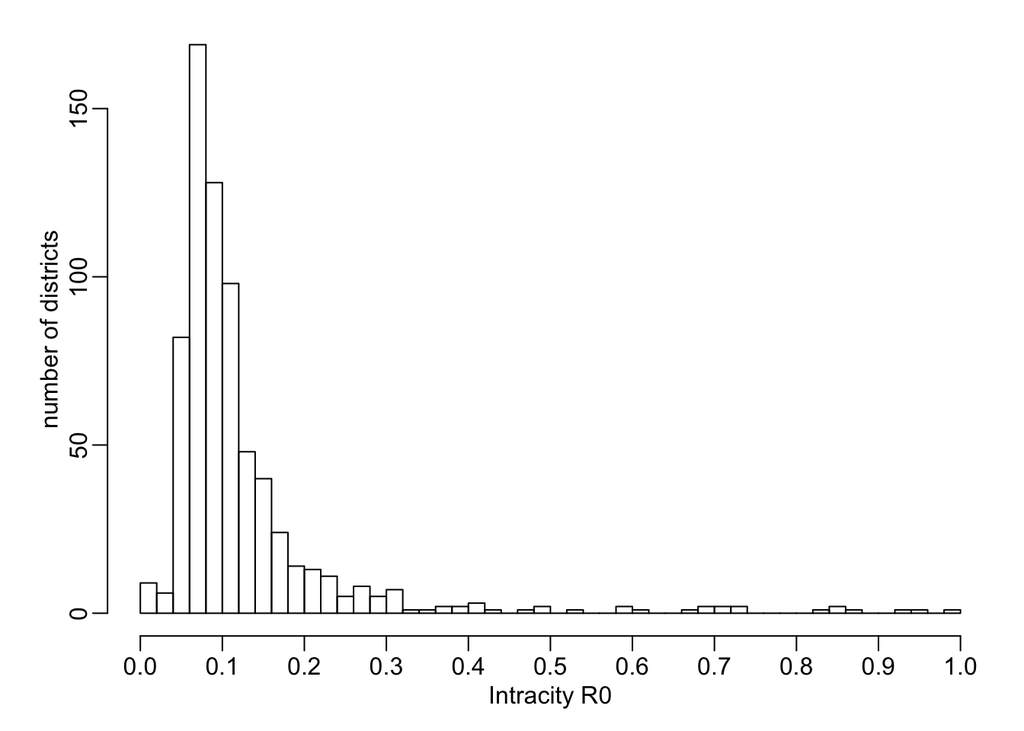

```r
hist2(ROIsf$ROI, n = 50, xlab = "Intracity R0", ylab = "number of districts", axes = FALSE)
axis(1, seq(0, 1, 0.1))
axis(2)
```

Let’s map the risk of infection to the districts:

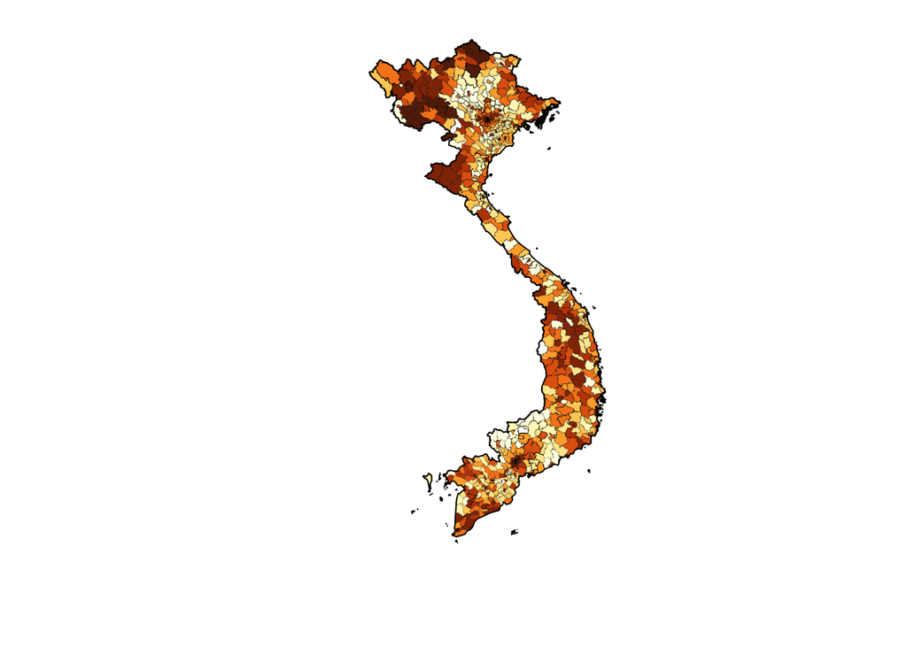

```r
ROIsf %>%
  st_geometry() %>%
  plot(lwd = .1, col = pal[cut(ROIsf$ROI, quantile(ROIsf$ROI, seq(0, 1, le = 11)))], main = NA)

vn0 %>%
  st_geometry() %>%
  plot(add = TRUE)
```

Let’s examine the relationship between population density and risk of infection:

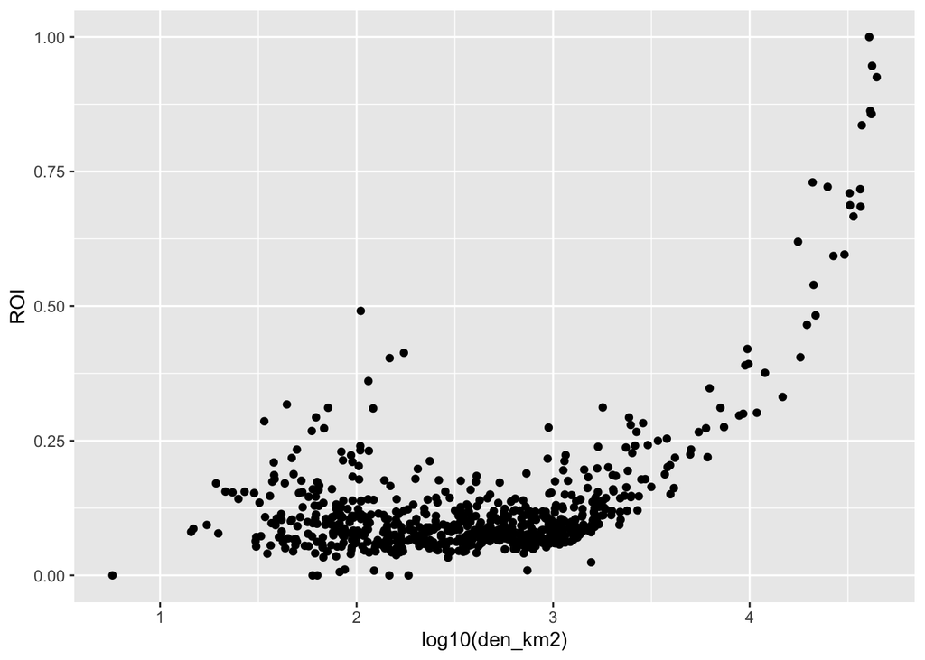

```r
ggplot(ROIsf, aes(x = log10(den_km2), y = ROI)) + geom_point()
```

Generally, risk of infection increases with population density. We see, however, that some populations with low densities have high risks of infection.

Let’s break down the risk of infection into risk of infection due to intracity transmission and risk of infection due to intercity transmission for each district.

```r
tmp <- totalInter %>%
  right_join(select(intracityR0, polygon1_id, intraR0, n), "polygon1_id") %>%
  rename(polygon_id = polygon1_id) %>%
  mutate(interROI = interR0 / (interR0 + intraR0)) %>%
  filter(interROI != "NaN")

interROI <- dist_polygons %>%
  right_join(select(tmp, polygon_id, interR0, intraR0, interROI), "polygon_id")
```

It look like this:

```r
interROI %>%
  arrange(desc(interROI)) %>%
  select(polygon_id, province, district, den_km2, interROI) %>%
  st_drop_geometry() %>%
  head(30)
```

```
##    polygon_id          province     district     den_km2  interROI
## 1      834334 Bà Rịa - Vũng Tàu      Côn Đảo    81.96605 1.0000000
## 2      834482        Kiên Giang     Kiên Hải   739.64350 1.0000000
## 3      834281         Quảng Nam       Hội An  1561.87028 1.0000000
## 4      834741        Quảng Ninh        Cô Tô   122.76955 1.0000000
## 5      834792        Quảng Ninh      Vân Đồn    87.10470 1.0000000
## 6      834869           Long An      Tân Trụ   662.14180 0.6387840
## 7      834346        Tiền Giang    Tân Phước   193.30883 0.5634492
## 8      834400        Quảng Ngãi     Sơn Tịnh   433.67214 0.5612937
## 9      834248         Thanh Hóa     Đông Sơn   965.41999 0.5547872
## 10     834706       Hồ Chí Minh       Nhà Bè  1190.04327 0.5365434
## 11     834876        Tiền Giang      Chợ Gạo   855.24199 0.5346049
## 12     834487           Cần Thơ     Cái Răng  1411.69547 0.5070858
## 13     834887          Nam Định       Mỹ Lộc  1036.96940 0.5060699
## 14     834343           Long An   Châu Thành   740.58097 0.4913874
```

[output cut: 16 more lines]

Let’s map the percent ROI attributable to intercity transmission:

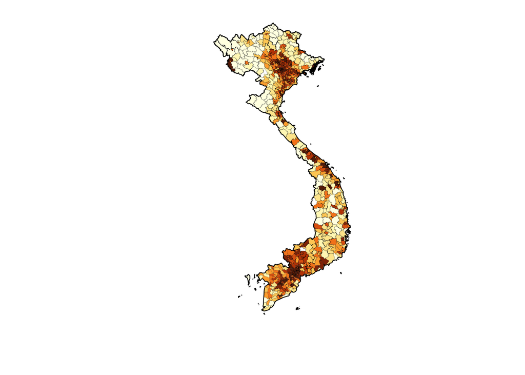

```r
interROI %>%
  st_geometry() %>%
  plot(lwd = .1, col = pal[cut(interROI$interROI, quantile(interROI$interROI, seq(0, 1, le = 11)))], main = NA)

vn0 %>%
  st_geometry() %>%
  plot(add = TRUE)
```